# EPIDP8451 Final Project - An applicatoin of machine learning to identify potential risk factors for early childhood asthma

Fang Liu (fl2569), Jing Wen (jw4061)

4/13/2022

# Reseach Background

## Research Question

What are the risk factors for predicting asthma diagnosis in children of early school age?

## Research Rationale

Asthma is the most common chronic airway disease of childhood. The etiology of asthma is not fully understood, but family history of the disease, respiratory infections, as well as environmental factors (e.g. airborne pollutants) may contribute to disease development. This study aims to identify modifiable risk factors of asthma for predicting asthma during early school age.

# Part 1 - Data preparation

## Data Cleaning & Preprocessing

In this step, we performed data cleaning for final dataset which included: 1) load data, 2) change categorical variables to factors, 3) strip ID variable, 4) check for missing values, 5) check if there is imbalance of outcome distribution, and 6) address collinearity by removing features with >0.8 correlation before modeling.

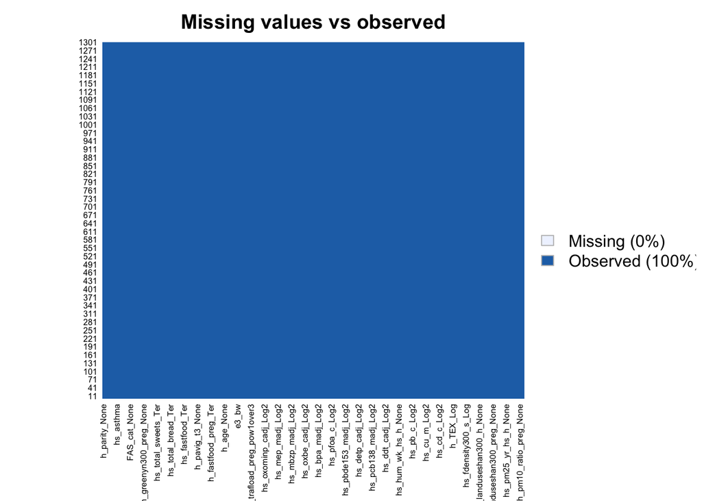

```r
#Load data
load("./exposome.RData")
data <- merge(exposome,phenotype,by="ID") %>% merge(covariates, by="ID")

#Strip off ID Variable
data$ID<-NULL

#make variable as factor
data$hs_asthma <- as.factor(data$hs_asthma) #241 features

# Finding correlated predictors
data_numeric <- data %>% select(where(is.numeric)) #180 features
data_categorical <- data %>% select(!where(is.numeric)) #61 features

correlations <- cor(data_numeric, use="complete.obs")
high.correlations <- findCorrelation(correlations, cutoff=0.8)

#findCorrelation() searches through a correlation matrix and returns a vector of integers corresponding to COLUMNS to remove to reduce pair-wise correlations

# Remove highly correlated features
data_numeric_low_corr <- data_numeric[,-high.correlations] #159 variables (continuous)

#Combine the low-correlated numerical variables & categorical variables
final_data = bind_cols(data_numeric_low_corr, data_categorical)
#1301 observations x 220 variables columns

#check missing data
missmap(final_data, main = "Missing values vs observed", x.cex = 0.5, y.cex = 0.5)
```

```r
#check if data is balanced
summary(final_data$hs_asthma) #very unbalanced 1159 vs. 142
```

```
##    0    1
## 1159  142
```

```r
#str(train_data$hs_asthma)
```

**Conclusion:** In the original dataset, there are 241 features (180 numerical variables + 61 categorical variables); We removed 21 highly correlated numeric variables (180-21=159), so we are left with 220 variables for feature selection for the next step.

## Data Partition

In this step, models would be trained on 70% of patient data (the training set) and tested on the remaining 30% (the test set) as an internal validation of the model.

```r
set.seed(100)
train_index <- createDataPartition(y=final_data$hs_asthma, p=0.7, list=FALSE)
train_data <- final_data[train_index,] #912
test_data <- final_data[-train_index,] #389
```

# Part 2 - Variable Selection

## Variable Selection using random forest (i.e., find which variables to include in model)

```r
set.seed(100)

#hyper parameter tuning: mtry
mtry_val2 <- c(ncol(train_data)-1, sqrt(ncol(train_data)-1), 0.5*ncol(train_data)-1)
mtry_grid <- expand.grid(.mtry=mtry_val2)

#5-fold cross-validation with upsampling
rf_asthma <- train(hs_asthma ~ ., data=train_data, method="rf", trControl=trainControl("cv", number=5, sampling="up"), metric="Accuracy", tuneGrid=mtry_grid, ntree=100)

rf_asthma$bestTune
```

```
##       mtry
## 1 14.79865
```

```r
rf_asthma$results
```

```
##        mtry  Accuracy        Kappa  AccuracySD     KappaSD
## 1  14.79865 0.8892572 -0.002103602 0.002257404 0.004703798
## 2 109.00000 0.8837687  0.015334993 0.006086021 0.031890455
## 3 219.00000 0.8739086  0.011565498 0.012211379 0.034041651
```

```r
rf_asthma$finalModel
```

```
##
## Call:
##  randomForest(x = x, y = y, ntree = 100, mtry = min(param$mtry,      ncol(x)))
##                Type of random forest: classification
##                      Number of trees: 100
## No. of variables tried at each split: 15
##
##         OOB estimate of  error rate: 0%
## Confusion matrix:
##     0   1 class.error
## 0 812   0           0
## 1   0 812           0
```

```r
confusionMatrix(rf_asthma)
```

```
## Cross-Validated (5 fold) Confusion Matrix
##
## (entries are percentual average cell counts across resamples)
##
##           Reference
## Prediction    0    1
##          0 88.9 11.0
##          1  0.1  0.0
##
##  Accuracy (average) : 0.8893
```

```r
#find which variables are considered "important"
varlist = varImp(rf_asthma)[["importance"]]
important_vars = varlist %>% filter(Overall > 50) %>% arrange(-Overall)

#predictors(rf_asthma)
#plot(varImp(rf_asthma), top=16)
#plot(rf_asthma)

#paste(rownames(important_vars), collapse = " + ")
```

**Conclusion:** Feature selection was done by a first round of 5-fold cross validated Random Forest model on the full predictor set after removing highly-correlated features (220 features). We used the top 16 features from this model’s feature importance (i.e., individual features with 50% importance or higher were selected). A complete list of predictor variables is as followed: hs_cd_m_Log2, h_trafnear_preg_pow1over3, h_builtdens300_preg_Sqrt, hs_pbde153_cadj_Log2, h_popdens_preg_Sqrt, hs_pfunda_m_Log2, hs_pfhxs_c_Log2, hs_ndvi100_s_None, hs_mehp_cadj_Log2, hs_dmtp_cadj_Log2, hs_ddt_cadj_Log2, h_ndvi100_preg_None, hs_dep_madj_Log2, hs_pm10_dy_hs_h_None, hs_pm25abs_wk_hs_h_Log, hs_cu_c_Log2.

### DEBUG ONLY

```r
#OPTION 1 - Only keep the variables deemed to be important by random forest in the model
set.seed(100)
train_data2 = train_data %>% select(rownames(important_vars), hs_asthma)

rf2_asthma <- train(hs_asthma ~ ., data=train_data2, method="rf", trControl=trainControl("cv", number=5, sampling="up"), metric="Accuracy", tuneGrid=mtry_grid, ntree=100)

#rf2_asthma[["resample"]]

rf2_asthma$results
```

```
##        mtry  Accuracy      Kappa AccuracySD    KappaSD
## 1  14.79865 0.8651174 0.10187128 0.01018181 0.12223098
## 2 109.00000 0.8662403 0.07815633 0.01247045 0.06935055
## 3 219.00000 0.8651174 0.10677066 0.01394873 0.06152901
```

```r
confusionMatrix(rf2_asthma)
```

```
## Cross-Validated (5 fold) Confusion Matrix
##
## (entries are percentual average cell counts across resamples)
##
##           Reference
## Prediction    0    1
##          0 85.5  9.9
##          1  3.5  1.1
##
##  Accuracy (average) : 0.8662
```

```r
#OPTION 2 - keep the original data, just change the model formula
set.seed(100)
#paste(rownames(important_vars), collapse = " + ")

rf3_asthma <- train(hs_asthma ~ hs_cd_m_Log2 + h_trafnear_preg_pow1over3 + h_builtdens300_preg_Sqrt + hs_pbde153_cadj_Log2 + h_popdens_preg_Sqrt + hs_pfunda_m_Log2 + hs_pfhxs_c_Log2 + hs_ndvi100_s_None + hs_mehp_cadj_Log2 + hs_dmtp_cadj_Log2 + hs_ddt_cadj_Log2 + h_ndvi100_preg_None + hs_dep_madj_Log2 + hs_pm10_dy_hs_h_None + hs_pm25abs_wk_hs_h_Log + hs_cu_c_Log2, data=train_data, method="rf", trControl=trainControl("cv", number=5, sampling="up"), metric="Accuracy", tuneGrid=mtry_grid, ntree=100)

rf3_asthma$results
```

```
##        mtry  Accuracy      Kappa AccuracySD    KappaSD
## 1  14.79865 0.8651174 0.10187128 0.01018181 0.12223098
## 2 109.00000 0.8662403 0.07815633 0.01247045 0.06935055
## 3 219.00000 0.8651174 0.10677066 0.01394873 0.06152901
```

```r
confusionMatrix(rf3_asthma)
```

```
## Cross-Validated (5 fold) Confusion Matrix
##
## (entries are percentual average cell counts across resamples)
##
##           Reference
## Prediction    0    1
##          0 85.5  9.9
##          1  3.5  1.1
##
##  Accuracy (average) : 0.8662
```

# Part 3 - Construct prediction models

## Model Building & Evaluation

In this step, several machine-learning methods were applied and assessed to predict asthma diagnosis. These methods include traditional logistic regression, Logistic Regression with regularization (Elastic Net), Support Vector Machine (SVM) and Bagging. To reduce the problem of imbalanced outcome distribution, imbalance corrections were used with Random upsampling which showed the better performance than downsampling.

In addition, to improve the robustness and avoid overfitting (lack of generalization), we used 10-fold cross-validation with group split for the model selection process on the training data.

### Model 1: Traditional Logistic regression

```r
set.seed(100)

logit_asthma <- train(hs_asthma ~ hs_cd_m_Log2 + h_trafnear_preg_pow1over3 + h_builtdens300_preg_Sqrt + hs_pbde153_cadj_Log2 + h_popdens_preg_Sqrt + hs_pfunda_m_Log2 + hs_pfhxs_c_Log2 + hs_ndvi100_s_None + hs_mehp_cadj_Log2 + hs_dmtp_cadj_Log2 + hs_ddt_cadj_Log2 + h_ndvi100_preg_None + hs_dep_madj_Log2 + hs_pm10_dy_hs_h_None + hs_pm25abs_wk_hs_h_Log + hs_cu_c_Log2, data = train_data, method="glm", family = "binomial", trControl=trainControl(method="cv", number = 10))

logit_asthma$results
```

```
##   parameter  Accuracy        Kappa  AccuracySD     KappaSD
## 1      none 0.8892499 -0.002038736 0.003593446 0.006447049
```

```r
confusionMatrix(logit_asthma) #0.8893
```

```
## Cross-Validated (10 fold) Confusion Matrix
##
## (entries are percentual average cell counts across resamples)
##
##           Reference
## Prediction    0    1
##          0 88.9 11.0
##          1  0.1  0.0
##
##  Accuracy (average) : 0.8893
```

### Model 2: Elastic Net (regularized regression)

```r
set.seed(100)

en_asthma <- train(hs_asthma ~ hs_cd_m_Log2 + h_trafnear_preg_pow1over3 + h_builtdens300_preg_Sqrt + hs_pbde153_cadj_Log2 + h_popdens_preg_Sqrt + hs_pfunda_m_Log2 + hs_pfhxs_c_Log2 + hs_ndvi100_s_None + hs_mehp_cadj_Log2 + hs_dmtp_cadj_Log2 + hs_ddt_cadj_Log2 + h_ndvi100_preg_None + hs_dep_madj_Log2 + hs_pm10_dy_hs_h_None + hs_pm25abs_wk_hs_h_Log + hs_cu_c_Log2,
                   data=train_data,
                   method="glmnet",
                   family="binomial",
                   trControl = trainControl("cv", number = 10, sampling= "up"),
                   tuneLength=10)

en_asthma$bestTune
```

```
##    alpha      lambda
## 52   0.8 0.001150063
```

```r
confusionMatrix(en_asthma) #accuracy - 0.6338
```

```
## Cross-Validated (10 fold) Confusion Matrix
##
## (entries are percentual average cell counts across resamples)
##
##           Reference
## Prediction    0    1
##          0 56.1  3.7
##          1 32.9  7.2
##
##  Accuracy (average) : 0.6338
```

```r
#predictors(en_asthma)
```

### Model 3: Support Vector Machine

Support Vector Machine (SVM) was used because it is capable of performing classification, regression and outlier detection. C is the tuning parameter that controls how much margin can be violated (i.e. how much classifications). Tuning paprameter C in our SVM model is **1.333667**.

```r
set.seed(100)

#train model
svm_asthma <- train(hs_asthma ~ hs_cd_m_Log2 + h_trafnear_preg_pow1over3 + h_builtdens300_preg_Sqrt + hs_pbde153_cadj_Log2 + h_popdens_preg_Sqrt + hs_pfunda_m_Log2 + hs_pfhxs_c_Log2 + hs_ndvi100_s_None + hs_mehp_cadj_Log2 + hs_dmtp_cadj_Log2 + hs_ddt_cadj_Log2 + h_ndvi100_preg_None + hs_dep_madj_Log2 + hs_pm10_dy_hs_h_None + hs_pm25abs_wk_hs_h_Log + hs_cu_c_Log2, data = train_data, method="svmLinear", trControl=trainControl(method="cv", number = 10, sampling="up"), preProcess = c("center","scale"), tuneGrid=expand.grid(C=seq(0.001,2,length=10)))

svm_asthma$bestTune
```

```
##          C
## 7 1.333667
```

```r
#x = svm_asthma$bestTune$C
#svm_asthma$results
confusionMatrix(svm_asthma) #0.5833
```

```
## Cross-Validated (10 fold) Confusion Matrix
##
## (entries are percentual average cell counts across resamples)
##
##           Reference
## Prediction    0    1
##          0 51.3  3.9
##          1 37.7  7.0
##
##  Accuracy (average) : 0.5833
```

### Model 4 - Bagging (ensemble)

```r
set.seed(100)

#Note: in bagging, ALL predictor features are eligible for selection at each node
#parameter tuning
mtry_val1 <- expand.grid(.mtry = c(ncol(train_data)-1, sqrt(ncol(train_data)-1), 0.5*ncol(train_data)-1))

bag_asthma<-train(hs_asthma ~ hs_cd_m_Log2 + h_trafnear_preg_pow1over3 + h_builtdens300_preg_Sqrt + hs_pbde153_cadj_Log2 + h_popdens_preg_Sqrt + hs_pfunda_m_Log2 + hs_pfhxs_c_Log2 + hs_ndvi100_s_None + hs_mehp_cadj_Log2 + hs_dmtp_cadj_Log2 + hs_ddt_cadj_Log2 + h_ndvi100_preg_None + hs_dep_madj_Log2 + hs_pm10_dy_hs_h_None + hs_pm25abs_wk_hs_h_Log + hs_cu_c_Log2,
                  data=train_data,
                  method="rf",
                  metric="Accuracy",
                  trControl = trainControl("cv", number = 10, sampling="up"),
                  tuneGrid=mtry_val1,
                  ntree=100) #10-fold cross-validation

bag_asthma$bestTune
```

```
##       mtry
## 1 14.79865
```

```r
bag_asthma$results
```

```
##        mtry  Accuracy     Kappa AccuracySD    KappaSD
## 1  14.79865 0.8760511 0.1312676 0.02159720 0.09890649
## 2 109.00000 0.8727783 0.1120056 0.02809448 0.16443867
## 3 219.00000 0.8705805 0.1347978 0.02540895 0.15982704
```

```r
confusionMatrix(bag_asthma) #pick the best model using accuracy - 0.8761
```

```
## Cross-Validated (10 fold) Confusion Matrix
##
## (entries are percentual average cell counts across resamples)
##
##           Reference
## Prediction    0    1
##          0 86.2  9.5
##          1  2.9  1.4
##
##  Accuracy (average) : 0.8761
```

## Model comparison

```r
#compare model performance using accuracy

confusionMatrix(logit_asthma) #Reference: 0.8893
```

```
## Cross-Validated (10 fold) Confusion Matrix
##
## (entries are percentual average cell counts across resamples)
##
##           Reference
## Prediction    0    1
##          0 88.9 11.0
##          1  0.1  0.0
##
##  Accuracy (average) : 0.8893
```

```r
confusionMatrix(en_asthma) #0.6338
```

```
## Cross-Validated (10 fold) Confusion Matrix
##
## (entries are percentual average cell counts across resamples)
##
##           Reference
## Prediction    0    1
##          0 56.1  3.7
##          1 32.9  7.2
##
##  Accuracy (average) : 0.6338
```

```r
confusionMatrix(svm_asthma) #0.5833
```

```
## Cross-Validated (10 fold) Confusion Matrix
##
## (entries are percentual average cell counts across resamples)
##
##           Reference
## Prediction    0    1
##          0 51.3  3.9
##          1 37.7  7.0
##
##  Accuracy (average) : 0.5833
```

```r
confusionMatrix(bag_asthma) #0.8728
```

```
## Cross-Validated (10 fold) Confusion Matrix
##
## (entries are percentual average cell counts across resamples)
##
##           Reference
## Prediction    0    1
##          0 86.2  9.5
##          1  2.9  1.4
##
##  Accuracy (average) : 0.8761
```

# Part 4 - Select final model & evaluate

### Evaluate final model performance using testing set

```r
asthma_pred = predict(bag_asthma, test_data)
asthma_pred_prob = predict(bag_asthma, test_data, type = "prob")

#Confusion Matrix
en_eval = confusionMatrix(asthma_pred, test_data$hs_asthma, positive = "1")
x = en_eval$overall[1] #accuracy

#AUC
auc = roc(response=test_data$hs_asthma, predictor=asthma_pred_prob[,2])
auc$auc #0.5467... very low
```

```
## Area under the curve: 0.4646
```

```r
#Variable importance
varImp(bag_asthma)
```

```
## rf variable importance
##
##                           Overall
## h_builtdens300_preg_Sqrt   100.00
## hs_cd_m_Log2                95.89
## hs_ndvi100_s_None           84.57
## h_popdens_preg_Sqrt         74.80
## h_trafnear_preg_pow1over3   74.68
## hs_dmtp_cadj_Log2           68.38
## hs_cu_c_Log2                65.66
## hs_pbde153_cadj_Log2        48.36
## hs_pfhxs_c_Log2             48.05
## hs_mehp_cadj_Log2           44.49
## hs_dep_madj_Log2            42.21
## hs_pm10_dy_hs_h_None        25.77
## hs_pfunda_m_Log2            25.14
## hs_pm25abs_wk_hs_h_Log      17.41
## hs_ddt_cadj_Log2            14.00
## h_ndvi100_preg_None          0.00
```

# Part 5 - Unsupervised (k-means)

```r
set.seed(100)

#exposome_test <- exposome %>% select(-1) %>% select(where(is.numeric))

#scale data
set.up.preprocess<-preProcess(data_numeric_low_corr, method=c("center", "scale"))
transformed.vals<-predict(set.up.preprocess, data_numeric_low_corr)

#Conduct a gap statistic analysis to determine optimal number of clusters
gap_stat<-clusGap(transformed.vals, FUN=kmeans, nstart=10, K.max=10, B=10, iter.max=50)
print(gap_stat, method="firstmax")
fviz_gap_stat(gap_stat) #6

#perform k-means & visualize the clusters
clusters<-kmeans(transformed.vals, 6, nstart=25)
str(clusters)
fviz_cluster(clusters, data=transformed.vals)
#Show the mean value of features within each cluster
clusters$centers

#combine original data and the clustering results
data_with_cluster <- cbind(data_numeric_low_corr,cluster=clusters$cluster)
```

[output not shown]

## Discussion

Limitations of the study: 1. our model would only be applicable to healthcare settings in other countries within Europe. 2. need external data samples for external validation - generalizability. 3. Ethical issus??